# Kaggle项目—— House Pricing

### 1. EDA

```python
#导入本项目所需要的库
import numpy as np
import pandas as pd
import matplotlib.pyplot as plt
%matplotlib inline
import seaborn as sns
```

```python
#导入本项目数据集
df_train = pd.read_csv('data/train.csv',index_col = 0)
df_test = pd.read_csv('data/test.csv',index_col = 0)
```

#### 探索train数据集

```python
df_train.shape
```

```
(1460, 80)
```

```python
df_train.info()
```

```
<class 'pandas.core.frame.DataFrame'>
Int64Index: 1460 entries, 1 to 1460
Data columns (total 80 columns):
MSSubClass       1460 non-null int64
MSZoning         1460 non-null object
LotFrontage      1201 non-null float64
LotArea          1460 non-null int64
Street           1460 non-null object
Alley            91 non-null object
LotShape         1460 non-null object
LandContour      1460 non-null object
Utilities        1460 non-null object
LotConfig        1460 non-null object
LandSlope        1460 non-null object
Neighborhood     1460 non-null object
Condition1       1460 non-null object
Condition2       1460 non-null object
BldgType         1460 non-null object
HouseStyle       1460 non-null object
OverallQual      1460 non-null int64
OverallCond      1460 non-null int64
YearBuilt        1460 non-null int64
YearRemodAdd     1460 non-null int64
RoofStyle        1460 non-null object
RoofMatl         1460 non-null object
Exterior1st      1460 non-null object
Exterior2nd      1460 non-null object
MasVnrType       1452 non-null object
MasVnrArea       1452 non-null float64
ExterQual        1460 non-null object
ExterCond        1460 non-null object
Foundation       1460 non-null object
BsmtQual         1423 non-null object
BsmtCond         1423 non-null object
BsmtExposure     1422 non-null object
BsmtFinType1     1423 non-null object
BsmtFinSF1       1460 non-null int64
BsmtFinType2     1422 non-null object
BsmtFinSF2       1460 non-null int64
BsmtUnfSF        1460 non-null int64
```

[output cut: 30 more lines]

```
EnclosedPorch    1460 non-null int64
3SsnPorch        1460 non-null int64
ScreenPorch      1460 non-null int64
PoolArea         1460 non-null int64
PoolQC           7 non-null object
Fence            281 non-null object
MiscFeature      54 non-null object
MiscVal          1460 non-null int64
MoSold           1460 non-null int64
YrSold           1460 non-null int64
SaleType         1460 non-null object
SaleCondition    1460 non-null object
SalePrice        1460 non-null int64
dtypes: float64(3), int64(34), object(43)
memory usage: 923.9+ KB
```

变量解释如下：

SalePrice - 房产销售价格，以美元计价。所要预测的目标变量。

MSSubClass: The building class 建筑等级

MSZoning: The general zoning classification 区域分类

LotFrontage: Linear feet of street connected to property 房子同街道之间的距离

LotArea: Lot size in square feet 建筑面积

Street: Type of road access 主路的路面类型

Alley: Type of alley access 小道的路面类型

LotShape: General shape of property 房屋外形

LandContour: Flatness of the property 平整度

Utilities: Type of utilities available 配套公用设施类型

LotConfig: Lot configuration 配置

LandSlope: Slope of property 土地坡度

Neighborhood: Physical locations within Ames city limits

Condition1: Proximity to main road or railroad 与主要公路及铁路的距离

Condition2: Proximity to main road or railroad (if a second is present) 与主要公路及铁路的距离

BldgType: Type of dwelling 住宅类型

HouseStyle: Style of dwelling 房屋的层数

OverallQual: Overall material and finish quality 完工质量和材料

OverallCond: Overall condition rating 整体条件等级

YearBuilt: Original construction date 建造年份

YearRemodAdd: Remodel date 翻修年份

RoofStyle: Type of roof 屋顶类型

RoofMatl: Roof material 屋顶材料

Exterior1st: Exterior covering on house 外立面材料

Exterior2nd: Exterior covering on house (if more than one material) 外立面材料2

MasVnrType: Masonry veneer type 装饰石材类型

MasVnrArea: Masonry veneer area in square feet 装饰石材面积

ExterQual: Exterior material quality 外立面材料质量

ExterCond: Present condition of the material on the exterior 外立面材料外观情况

Foundation: Type of foundation 基础类型

BsmtQual: Height of the basement 地下室高度

BsmtCond: General condition of the basement 地下室总体情况

BsmtExposure: Walkout or garden level basement walls 地下室出口或者花园层的墙面

BsmtFinType1: Quality of basement finished area 地下室区域质量

BsmtFinSF1: Type 1 finished square feet Type 1完工面积

BsmtFinType2: Quality of second finished area (if present) 二次完工面积质量（如果有）

BsmtFinSF2: Type 2 finished square feet Type 2完工面积

BsmtUnfSF: Unfinished square feet of basement area 地下室区域未完工面积

TotalBsmtSF: Total square feet of basement area 地下室总体面积

Heating: Type of heating 采暖类型

HeatingQC: Heating quality and condition 采暖质量和条件

CentralAir: Central air conditioning 中央空调系统

Electrical: Electrical system 电力系统

1stFlrSF: First Floor square feet 第一层面积

2ndFlrSF: Second floor square feet 第二层面积

LowQualFinSF: Low quality finished square feet (all floors) 低质量完工面积

GrLivArea: Above grade (ground) living area square feet 地面以上部分起居面积

BsmtFullBath: Basement full bathrooms 地下室全浴室

BsmtHalfBath: Basement half bathrooms 地下室半浴室

FullBath: Full bathrooms above grade 地面以上全浴室

HalfBath: Half baths above grade 地面以上半浴室

Bedroom: Number of bedrooms above basement level 地面以上卧室

Kitchen: Number of kitchens 厨房数量

KitchenQual: Kitchen quality 厨房质量

TotRmsAbvGrd: Total rooms above grade (does not include bathrooms) 总房间数（不含浴室和地下部分）

Functional: Home functionality rating 功能性评级

Fireplaces: Number of fireplaces 壁炉数量

FireplaceQu: Fireplace quality 壁炉质量

GarageType: Garage location 车库位置

GarageYrBlt: Year garage was built 车库建造时间

GarageFinish: Interior finish of the garage 车库中间建成时间（比如翻修）

GarageCars: Size of garage in car capacity 车库大小以停车数量表示

GarageArea: Size of garage in square feet 车库面积

GarageQual: Garage quality 车库质量

GarageCond: Garage condition 车库条件

PavedDrive: Paved driveway 硬化路面

WoodDeckSF: Wood deck area in square feet 实木地板面积

OpenPorchSF: Open porch area in square feet 开放式门廊面积

EnclosedPorch: Enclosed porch area in square feet 封闭式门廊面积

3SsnPorch: Three season porch area in square feet 时令门廊面积

ScreenPorch: Screen porch area in square feet 屏幕门廊面积

PoolArea: Pool area in square feet 游泳池面积

PoolQC: Pool quality 游泳池质量

Fence: Fence quality 围栏质量

MiscFeature: Miscellaneous feature not covered in other categories 其它条件中未包含部分的特性

MiscVal: $Value of miscellaneous feature

MoSold: Month Sold 卖出月份

YrSold: Year Sold 卖出年份

SaleType: Type of sale 出售类型

SaleCondition: Condition of sale 出售条件

```python
df_train.head()
```

| Id | MSSubClass | MSZoning | LotFrontage | LotArea | Street | Alley | LotShape | LandContour | Utilities | LotConfig | ... | PoolArea | PoolQC | Fence | MiscFeature | MiscVal | MoSold | YrSold | SaleType | SaleCondition | SalePrice |
| --- | --- | --- | --- | --- | --- | --- | --- | --- | --- | --- | --- | --- | --- | --- | --- | --- | --- | --- | --- | --- | --- |
| 1 | 60 | RL | 65.0 | 8450 | Pave | NaN | Reg | Lvl | AllPub | Inside | ... | 0 | NaN | NaN | NaN | 0 | 2 | 2008 | WD | Normal | 208500 |
| 2 | 20 | RL | 80.0 | 9600 | Pave | NaN | Reg | Lvl | AllPub | FR2 | ... | 0 | NaN | NaN | NaN | 0 | 5 | 2007 | WD | Normal | 181500 |
| 3 | 60 | RL | 68.0 | 11250 | Pave | NaN | IR1 | Lvl | AllPub | Inside | ... | 0 | NaN | NaN | NaN | 0 | 9 | 2008 | WD | Normal | 223500 |
| 4 | 70 | RL | 60.0 | 9550 | Pave | NaN | IR1 | Lvl | AllPub | Corner | ... | 0 | NaN | NaN | NaN | 0 | 2 | 2006 | WD | Abnorml | 140000 |
| 5 | 60 | RL | 84.0 | 14260 | Pave | NaN | IR1 | Lvl | AllPub | FR2 | ... | 0 | NaN | NaN | NaN | 0 | 12 | 2008 | WD | Normal | 250000 |

5 rows × 80 columns

```python
df_train.describe()
```

|  | MSSubClass | LotFrontage | LotArea | OverallQual | OverallCond | YearBuilt | YearRemodAdd | MasVnrArea | BsmtFinSF1 | BsmtFinSF2 | ... | WoodDeckSF | OpenPorchSF | EnclosedPorch | 3SsnPorch | ScreenPorch | PoolArea | MiscVal | MoSold | YrSold | SalePrice |
| --- | --- | --- | --- | --- | --- | --- | --- | --- | --- | --- | --- | --- | --- | --- | --- | --- | --- | --- | --- | --- | --- |
| count | 1460.000000 | 1201.000000 | 1460.000000 | 1460.000000 | 1460.000000 | 1460.000000 | 1460.000000 | 1452.000000 | 1460.000000 | 1460.000000 | ... | 1460.000000 | 1460.000000 | 1460.000000 | 1460.000000 | 1460.000000 | 1460.000000 | 1460.000000 | 1460.000000 | 1460.000000 | 1460.000000 |
| mean | 56.897260 | 70.049958 | 10516.828082 | 6.099315 | 5.575342 | 1971.267808 | 1984.865753 | 103.685262 | 443.639726 | 46.549315 | ... | 94.244521 | 46.660274 | 21.954110 | 3.409589 | 15.060959 | 2.758904 | 43.489041 | 6.321918 | 2007.815753 | 180921.195890 |
| std | 42.300571 | 24.284752 | 9981.264932 | 1.382997 | 1.112799 | 30.202904 | 20.645407 | 181.066207 | 456.098091 | 161.319273 | ... | 125.338794 | 66.256028 | 61.119149 | 29.317331 | 55.757415 | 40.177307 | 496.123024 | 2.703626 | 1.328095 | 79442.502883 |
| min | 20.000000 | 21.000000 | 1300.000000 | 1.000000 | 1.000000 | 1872.000000 | 1950.000000 | 0.000000 | 0.000000 | 0.000000 | ... | 0.000000 | 0.000000 | 0.000000 | 0.000000 | 0.000000 | 0.000000 | 0.000000 | 1.000000 | 2006.000000 | 34900.000000 |
| 25% | 20.000000 | 59.000000 | 7553.500000 | 5.000000 | 5.000000 | 1954.000000 | 1967.000000 | 0.000000 | 0.000000 | 0.000000 | ... | 0.000000 | 0.000000 | 0.000000 | 0.000000 | 0.000000 | 0.000000 | 0.000000 | 5.000000 | 2007.000000 | 129975.000000 |
| 50% | 50.000000 | 69.000000 | 9478.500000 | 6.000000 | 5.000000 | 1973.000000 | 1994.000000 | 0.000000 | 383.500000 | 0.000000 | ... | 0.000000 | 25.000000 | 0.000000 | 0.000000 | 0.000000 | 0.000000 | 0.000000 | 6.000000 | 2008.000000 | 163000.000000 |
| 75% | 70.000000 | 80.000000 | 11601.500000 | 7.000000 | 6.000000 | 2000.000000 | 2004.000000 | 166.000000 | 712.250000 | 0.000000 | ... | 168.000000 | 68.000000 | 0.000000 | 0.000000 | 0.000000 | 0.000000 | 0.000000 | 8.000000 | 2009.000000 | 214000.000000 |
| max | 190.000000 | 313.000000 | 215245.000000 | 10.000000 | 9.000000 | 2010.000000 | 2010.000000 | 1600.000000 | 5644.000000 | 1474.000000 | ... | 857.000000 | 547.000000 | 552.000000 | 508.000000 | 480.000000 | 738.000000 | 15500.000000 | 12.000000 | 2010.000000 | 755000.000000 |

8 rows × 37 columns

```python
df_train['SalePrice'].describe()
```

```
count      1460.000000
mean     180921.195890
std       79442.502883
min       34900.000000
25%      129975.000000
50%      163000.000000
75%      214000.000000
max      755000.000000
Name: SalePrice, dtype: float64
```

```
Text(0.5,1,'the distribution of SalePrice')
```

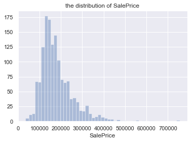

```python
# 观察train数据集中SalePrice的分布
sns.set()
sns.distplot(df_train['SalePrice'], kde=False)
plt.title('the distribution of SalePrice')
```

```
Text(0.5,0,'log1p(SalePrice)')
```

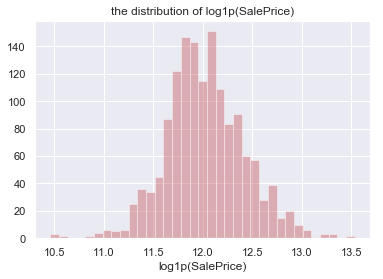

```python
# 观察log1p（SalePrice）的分布
sns.distplot(np.log1p(df_train['SalePrice']), kde=False, color = 'R')
plt.title('the distribution of log1p(SalePrice)')
plt.xlabel('log1p(SalePrice)')
```

```python
print("偏度: %f" % df_train['SalePrice'].skew())
print("峰度: %f" % df_train['SalePrice'].kurt())
```

```
偏度: 1.882876
峰度: 6.536282
```

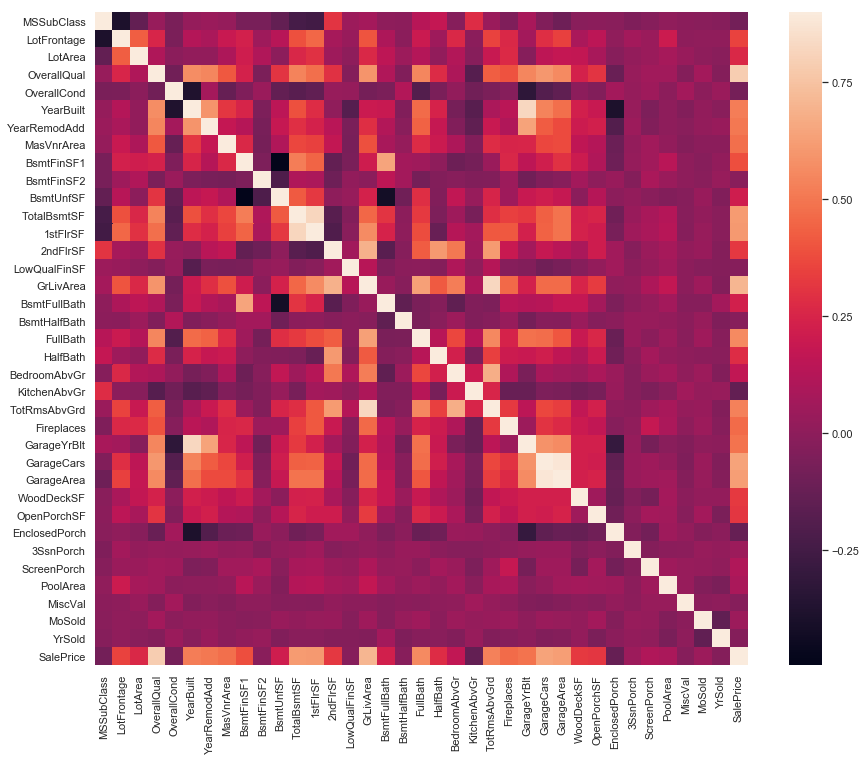

```python
# 相关系数矩阵
corrmat = df_train.corr()
f, ax = plt.subplots(figsize=(15, 12))
sns.heatmap(corrmat, vmax=0.9, square=True);
```

有一些变量之间存在比较强相关性，比如Garage系列，Bsmt系列。

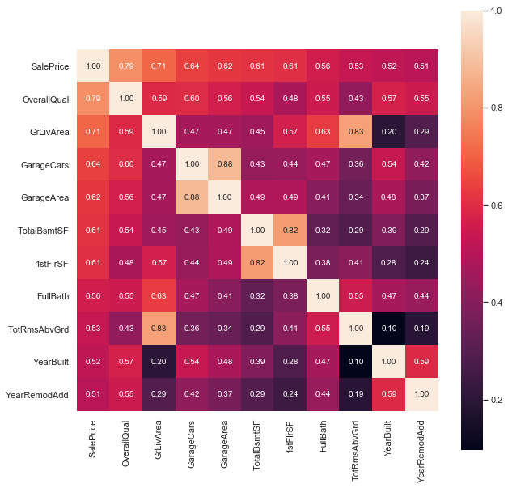

```
SalePrice       1.000000
OverallQual     0.790982
GrLivArea       0.708624
GarageCars      0.640409
GarageArea      0.623431
TotalBsmtSF     0.613581
1stFlrSF        0.605852
FullBath        0.560664
TotRmsAbvGrd    0.533723
YearBuilt       0.522897
YearRemodAdd    0.507101
GarageYrBlt     0.486362
MasVnrArea      0.477493
Fireplaces      0.466929
BsmtFinSF1      0.386420
LotFrontage     0.351799
WoodDeckSF      0.324413
2ndFlrSF        0.319334
OpenPorchSF     0.315856
Name: SalePrice, dtype: float64
```

```python
# SalePrice相关系数图，取前10个变量（不包括SalePrice）
corr_train = df_train.corr()

plt.figure(figsize=(10,10))
k = 11
cols = corr_train.nlargest(k, 'SalePrice')['SalePrice'].index
cm = np.corrcoef(df_train[cols].values.T)
hm = sns.heatmap(cm, cbar = True, annot = True, square = True, fmt='.2f', annot_kws={'size': 10}, yticklabels = cols.values, xticklabels = cols.values)
plt.show()

# 探索与SalePrice相关性绝对值大于0.3的变量
corr_train[(corr_train['SalePrice'] > 0.3)|(corr_train['SalePrice'] < -0.3)]['SalePrice'].sort_values(ascending = False)
```

```
Text(0.5,1,'OverallQual VS SalePrice')
```

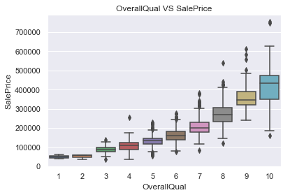

```python
# OverallQual与SalePrice箱线图
sns.boxplot(x = df_train['OverallQual'], y = df_train['SalePrice'])
plt.title('OverallQual VS SalePrice')
```

```
Text(0.5,1,'GrLivArea VS SalePrice')
```

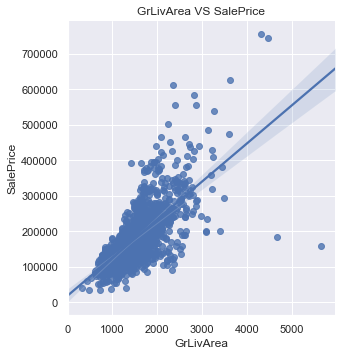

```python
# GrLivArea与SalePrice散点图
sns.lmplot(x = 'GrLivArea', y = 'SalePrice', data = df_train)
plt.title('GrLivArea VS SalePrice')
```

```
Text(0.5,1,'GarageCars VS SalePrice')
```

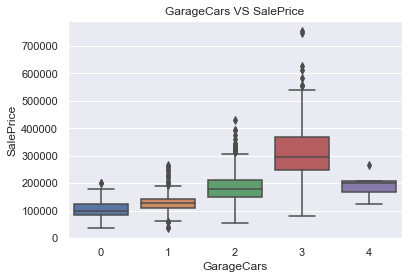

```python
# GarageCars与SalePrice箱线图
sns.boxplot(x = df_train['GarageCars'], y = df_train['SalePrice'])
plt.title('GarageCars VS SalePrice')
```

```
Text(0.5,1,'TotalBsmtSF VS SalePrice')
```

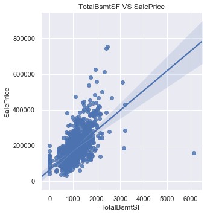

```python
# TotalBsmtSF与SalePrice散点图
sns.lmplot(x = 'TotalBsmtSF', y = 'SalePrice', data = df_train)
plt.title('TotalBsmtSF VS SalePrice')
```

```
Text(0.5,1,'FullBath VS SalePrice')
```

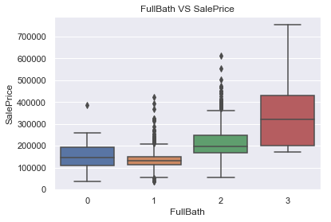

```python
# FullBath与SalePrice箱线图
sns.boxplot(x = df_train['FullBath'], y = df_train['SalePrice'])
plt.title('FullBath VS SalePrice')
```

```
Text(0.5,1,'YearBuilt VS SalePrice')
```

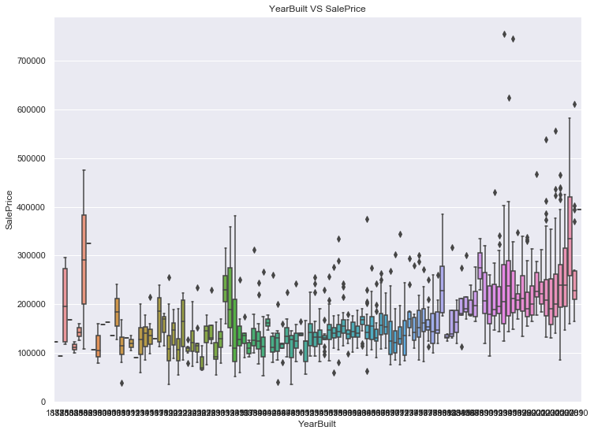

```python
# YearBuilt与SalePrice箱线图
plt.figure(figsize=(12,9))
sns.boxplot(x = df_train['YearBuilt'], y = df_train['SalePrice'])
plt.title('YearBuilt VS SalePrice')
```

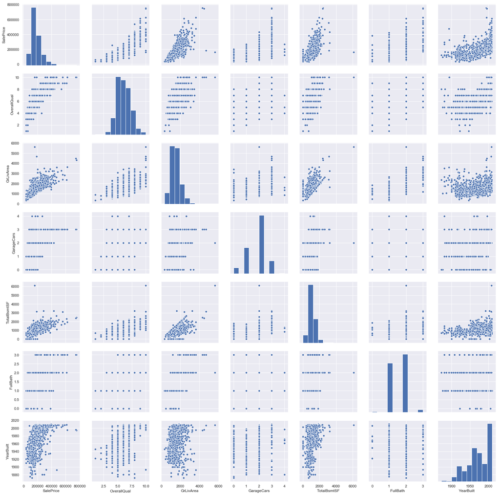

```python
cols = ['SalePrice', 'OverallQual', 'GrLivArea','GarageCars', 'TotalBsmtSF', 'FullBath', 'YearBuilt']
sns.pairplot(df_train[cols], height = 3)
plt.show()
```

#### 观察test数据集

```python
df_test.shape
```

```
(1459, 79)
```

```python
df_test.info()
```

```
<class 'pandas.core.frame.DataFrame'>
Int64Index: 1459 entries, 1461 to 2919
Data columns (total 79 columns):
MSSubClass       1459 non-null int64
MSZoning         1455 non-null object
LotFrontage      1232 non-null float64
LotArea          1459 non-null int64
Street           1459 non-null object
Alley            107 non-null object
LotShape         1459 non-null object
LandContour      1459 non-null object
Utilities        1457 non-null object
LotConfig        1459 non-null object
LandSlope        1459 non-null object
Neighborhood     1459 non-null object
Condition1       1459 non-null object
Condition2       1459 non-null object
BldgType         1459 non-null object
HouseStyle       1459 non-null object
OverallQual      1459 non-null int64
OverallCond      1459 non-null int64
YearBuilt        1459 non-null int64
YearRemodAdd     1459 non-null int64
RoofStyle        1459 non-null object
RoofMatl         1459 non-null object
Exterior1st      1458 non-null object
Exterior2nd      1458 non-null object
MasVnrType       1443 non-null object
MasVnrArea       1444 non-null float64
ExterQual        1459 non-null object
ExterCond        1459 non-null object
Foundation       1459 non-null object
BsmtQual         1415 non-null object
BsmtCond         1414 non-null object
BsmtExposure     1415 non-null object
BsmtFinType1     1417 non-null object
BsmtFinSF1       1458 non-null float64
BsmtFinType2     1417 non-null object
BsmtFinSF2       1458 non-null float64
BsmtUnfSF        1458 non-null float64
```

[output cut: 29 more lines]

```
OpenPorchSF      1459 non-null int64
EnclosedPorch    1459 non-null int64
3SsnPorch        1459 non-null int64
ScreenPorch      1459 non-null int64
PoolArea         1459 non-null int64
PoolQC           3 non-null object
Fence            290 non-null object
MiscFeature      51 non-null object
MiscVal          1459 non-null int64
MoSold           1459 non-null int64
YrSold           1459 non-null int64
SaleType         1458 non-null object
SaleCondition    1459 non-null object
dtypes: float64(11), int64(25), object(43)
memory usage: 911.9+ KB
```

```python
# 查看test中是否有元素不在train中
col = []
for column in df_test.columns:
    col.append(column not in df_train.columns)
print (col.count(True))
```

```
0
```

### 2. 数据清洗

为数据清洗方便，先将train数据集与test数据集合并，后续训练再分开

缺失值处理

```python
df_all = pd.concat((df_train, df_test), axis = 0)
```

[output not shown]

```python
df_all.shape
```

```
(2919, 80)
```

```python
df_all.info()
```

```
<class 'pandas.core.frame.DataFrame'>
Int64Index: 2919 entries, 1 to 2919
Data columns (total 80 columns):
1stFlrSF         2919 non-null int64
2ndFlrSF         2919 non-null int64
3SsnPorch        2919 non-null int64
Alley            198 non-null object
BedroomAbvGr     2919 non-null int64
BldgType         2919 non-null object
BsmtCond         2837 non-null object
BsmtExposure     2837 non-null object
BsmtFinSF1       2918 non-null float64
BsmtFinSF2       2918 non-null float64
BsmtFinType1     2840 non-null object
BsmtFinType2     2839 non-null object
BsmtFullBath     2917 non-null float64
BsmtHalfBath     2917 non-null float64
BsmtQual         2838 non-null object
BsmtUnfSF        2918 non-null float64
CentralAir       2919 non-null object
Condition1       2919 non-null object
Condition2       2919 non-null object
Electrical       2918 non-null object
EnclosedPorch    2919 non-null int64
ExterCond        2919 non-null object
ExterQual        2919 non-null object
Exterior1st      2918 non-null object
Exterior2nd      2918 non-null object
Fence            571 non-null object
FireplaceQu      1499 non-null object
Fireplaces       2919 non-null int64
Foundation       2919 non-null object
FullBath         2919 non-null int64
Functional       2917 non-null object
GarageArea       2918 non-null float64
GarageCars       2918 non-null float64
GarageCond       2760 non-null object
GarageFinish     2760 non-null object
GarageQual       2760 non-null object
GarageType       2762 non-null object
```

[output cut: 30 more lines]

```
RoofStyle        2919 non-null object
SaleCondition    2919 non-null object
SalePrice        1460 non-null float64
SaleType         2918 non-null object
ScreenPorch      2919 non-null int64
Street           2919 non-null object
TotRmsAbvGrd     2919 non-null int64
TotalBsmtSF      2918 non-null float64
Utilities        2917 non-null object
WoodDeckSF       2919 non-null int64
YearBuilt        2919 non-null int64
YearRemodAdd     2919 non-null int64
YrSold           2919 non-null int64
dtypes: float64(12), int64(25), object(43)
memory usage: 1.8+ MB
```

```python
# 观察df_all中的缺失值的比例
missing = df_all.isnull().sum()
missing_count = missing[missing > 0].sort_values(ascending=False)
missing_rate = missing_count / len(df_all)
missing_data = pd.concat([missing_count,missing_rate], axis=1, keys=['count','ratio'])
missing_data
```

|  | count | ratio |
| --- | --- | --- |
| PoolQC | 2909 | 0.996574 |
| MiscFeature | 2814 | 0.964029 |
| Alley | 2721 | 0.932169 |
| Fence | 2348 | 0.804385 |
| SalePrice | 1459 | 0.499829 |
| FireplaceQu | 1420 | 0.486468 |
| LotFrontage | 486 | 0.166495 |
| GarageQual | 159 | 0.054471 |
| GarageCond | 159 | 0.054471 |
| GarageFinish | 159 | 0.054471 |
| GarageYrBlt | 159 | 0.054471 |
| GarageType | 157 | 0.053786 |
| BsmtExposure | 82 | 0.028092 |
| BsmtCond | 82 | 0.028092 |
| BsmtQual | 81 | 0.027749 |
| BsmtFinType2 | 80 | 0.027407 |
| BsmtFinType1 | 79 | 0.027064 |
| MasVnrType | 24 | 0.008222 |
| MasVnrArea | 23 | 0.007879 |
| MSZoning | 4 | 0.001370 |
| BsmtFullBath | 2 | 0.000685 |
| BsmtHalfBath | 2 | 0.000685 |
| Utilities | 2 | 0.000685 |
| Functional | 2 | 0.000685 |
| Electrical | 1 | 0.000343 |
| BsmtUnfSF | 1 | 0.000343 |
| Exterior1st | 1 | 0.000343 |
| Exterior2nd | 1 | 0.000343 |
| TotalBsmtSF | 1 | 0.000343 |
| GarageCars | 1 | 0.000343 |
| BsmtFinSF2 | 1 | 0.000343 |
| BsmtFinSF1 | 1 | 0.000343 |
| KitchenQual | 1 | 0.000343 |
| SaleType | 1 | 0.000343 |
| GarageArea | 1 | 0.000343 |

```python
# PoolQC相关，查看PoolQC为空值，但PoolArea不为0的值
print(df_all[(df_all['PoolQC'].isnull()) & (df_all['PoolArea']!=0)][['PoolQC','PoolArea']])
print(df_all[(df_all['PoolQC'].notnull()) & (df_all['PoolArea']==0)][['PoolQC','PoolArea']])
```

```
     PoolQC  PoolArea
Id
2421    NaN       368
2504    NaN       444
2600    NaN       561
Empty DataFrame
Columns: [PoolQC, PoolArea]
Index: []
```

```python
df_all['PoolQC'] = df_all['PoolQC'].replace(df_all[(df_all['PoolQC'].isnull()) & (df_all['PoolArea']!=0)]['PoolQC'], 'Ex')
```

```python
# FireplaceQu相关，查看FireplaceQu为空值，但Fireplaces不为0的值
print(df_all[(df_train['FireplaceQu'].isnull()) & (df_all['Fireplaces'] != 0)][['FireplaceQu']])
```

```
Empty DataFrame
Columns: [FireplaceQu]
Index: []
```

```python
# PoolQC用None填充
df_all['PoolQC'].fillna('None', inplace = True)

# MiscFeature用None填充
df_all['MiscFeature'].fillna('None', inplace = True)

# Alley用None填充
df_all['Alley'].fillna('None', inplace = True)

# Fence用None填充
df_all['Fence'].fillna('None', inplace = True)

# FireplaceQu用None填充
df_all['FireplaceQu'].fillna('None', inplace = True)
```

```python
# Garage相关变量的值缺失是由没有车库造成的，用None替代
GarageX = ['GarageYrBlt','GarageType','GarageFinish','GarageQual','GarageCond']
for i in GarageX:
    df_all[i].fillna('None', inplace = True)
```

```python
# Bsmt相关变量的值缺失是由没有地下室造成的，用None替代
BsmtX = ['BsmtFinType2','BsmtFinType1','BsmtCond','BsmtExposure','BsmtQual']
for i in BsmtX:
    df_all[i].fillna('None', inplace = True)
```

```python
# MasVnrArea，装饰石材面积，缺失值用0替代
df_all['MasVnrArea'].fillna(0, inplace = True)
```

```python
# MasVnrType，装饰石材类型，缺失值用None替代
df_all['MasVnrType'].fillna('None', inplace = True)
```

```python
# LotFrontage，房子同街道之间的距离，缺失值较多，但与SalePrice相关系数大于0.3，保留变量，缺失值用中值替代
df_all['LotFrontage'] = df_all.groupby('Neighborhood')['LotFrontage'].transform(lambda x: x.fillna(x.median()))
```

```python
# Electrical，电力系统，缺失值直接删除整行
df_all = df_all.drop(df_all.loc[df_all['Electrical'].isnull()].index)
```

```python
list1 = ['MasVnrType','MSZoning','Functional','Utilities','SaleType','KitchenQual',
         'Exterior2nd','Exterior1st','Functional']
for i in list1:
    df_all[i].fillna('None', inplace = True)
```

```python
list2 = ['MasVnrArea','BsmtFinSF2','BsmtUnfSF','BsmtFinSF1','TotalBsmtSF','GarageCars','GarageArea','BsmtFullBath','BsmtHalfBath']

for i in list2:
    df_all[i].fillna(0, inplace = True)
```

```python
df_all.shape
```

```
(2918, 80)
```

```python
df_all.info()
```

```
<class 'pandas.core.frame.DataFrame'>
Int64Index: 2918 entries, 1 to 2919
Data columns (total 80 columns):
1stFlrSF         2918 non-null int64
2ndFlrSF         2918 non-null int64
3SsnPorch        2918 non-null int64
Alley            2918 non-null object
BedroomAbvGr     2918 non-null int64
BldgType         2918 non-null object
BsmtCond         2918 non-null object
BsmtExposure     2918 non-null object
BsmtFinSF1       2918 non-null float64
BsmtFinSF2       2918 non-null float64
BsmtFinType1     2918 non-null object
BsmtFinType2     2918 non-null object
BsmtFullBath     2918 non-null float64
BsmtHalfBath     2918 non-null float64
BsmtQual         2918 non-null object
BsmtUnfSF        2918 non-null float64
CentralAir       2918 non-null object
Condition1       2918 non-null object
Condition2       2918 non-null object
Electrical       2918 non-null object
EnclosedPorch    2918 non-null int64
ExterCond        2918 non-null object
ExterQual        2918 non-null object
Exterior1st      2918 non-null object
Exterior2nd      2918 non-null object
Fence            2918 non-null object
FireplaceQu      2918 non-null object
Fireplaces       2918 non-null int64
Foundation       2918 non-null object
FullBath         2918 non-null int64
Functional       2918 non-null object
GarageArea       2918 non-null float64
GarageCars       2918 non-null float64
GarageCond       2918 non-null object
GarageFinish     2918 non-null object
GarageQual       2918 non-null object
GarageType       2918 non-null object
```

[output cut: 30 more lines]

```
RoofStyle        2918 non-null object
SaleCondition    2918 non-null object
SalePrice        1459 non-null float64
SaleType         2918 non-null object
ScreenPorch      2918 non-null int64
Street           2918 non-null object
TotRmsAbvGrd     2918 non-null int64
TotalBsmtSF      2918 non-null float64
Utilities        2918 non-null object
WoodDeckSF       2918 non-null int64
YearBuilt        2918 non-null int64
YearRemodAdd     2918 non-null int64
YrSold           2918 non-null int64
dtypes: float64(11), int64(25), object(44)
memory usage: 1.8+ MB
```

```python
df_all.isnull().sum()[df_all.isnull().sum() > 0]
```

```
SalePrice    1459
dtype: int64
```

缺失值处理完毕，接下来处理异常值

```python
# 删除异常点
df_all.drop(df_all[(df_all['GrLivArea']> 4000)&(df_all['SalePrice']< 400000)].index,inplace=True)
df_all.drop(df_all[(df_all['TotalBsmtSF']> 6000)].index,inplace=True)
```

异常点处理完毕，接下来处理数据类型

```python
# 将df_all的变量按照object类型和非object分类
ob_col = df_all.columns[df_all.dtypes == 'object']
num_col = df_all.columns[df_all.dtypes != 'object']
```

```python
len(ob_col), ob_col
```

```
(44, Index(['Alley', 'BldgType', 'BsmtCond', 'BsmtExposure', 'BsmtFinType1',
        'BsmtFinType2', 'BsmtQual', 'CentralAir', 'Condition1', 'Condition2',
        'Electrical', 'ExterCond', 'ExterQual', 'Exterior1st', 'Exterior2nd',
        'Fence', 'FireplaceQu', 'Foundation', 'Functional', 'GarageCond',
        'GarageFinish', 'GarageQual', 'GarageType', 'GarageYrBlt', 'Heating',
        'HeatingQC', 'HouseStyle', 'KitchenQual', 'LandContour', 'LandSlope',
        'LotConfig', 'LotShape', 'MSZoning', 'MasVnrType', 'MiscFeature',
        'Neighborhood', 'PavedDrive', 'PoolQC', 'RoofMatl', 'RoofStyle',
        'SaleCondition', 'SaleType', 'Street', 'Utilities'],
       dtype='object'))
```

```python
len(num_col), num_col
```

```
(36, Index(['1stFlrSF', '2ndFlrSF', '3SsnPorch', 'BedroomAbvGr', 'BsmtFinSF1',
        'BsmtFinSF2', 'BsmtFullBath', 'BsmtHalfBath', 'BsmtUnfSF',
        'EnclosedPorch', 'Fireplaces', 'FullBath', 'GarageArea', 'GarageCars',
        'GrLivArea', 'HalfBath', 'KitchenAbvGr', 'LotArea', 'LotFrontage',
        'LowQualFinSF', 'MSSubClass', 'MasVnrArea', 'MiscVal', 'MoSold',
        'OpenPorchSF', 'OverallCond', 'OverallQual', 'PoolArea', 'SalePrice',
        'ScreenPorch', 'TotRmsAbvGrd', 'TotalBsmtSF', 'WoodDeckSF', 'YearBuilt',
        'YearRemodAdd', 'YrSold'],
       dtype='object'))
```

```python
# num_col中的'MSSubClass','OverallQual','OverallCond','YearBuilt', 'YearRemodAdd', 'MiscVal', 'MoSold', 'YrSold'为非连续变量,可以转化为object
df_all[['MSSubClass','OverallQual','OverallCond','YearBuilt', 'YearRemodAdd', 'MiscVal', 'MoSold', 'YrSold']] = df_all[['MSSubClass','OverallQual','OverallCond','YearBuilt', 'YearRemodAdd', 'MiscVal', 'MoSold', 'YrSold']].astype(str)
```

```python
ob_col = df_all.columns[df_all.dtypes == 'object']
len(ob_col)
```

```
52
```

```python
num_col = df_all.columns[df_all.dtypes != 'object']
len(num_col)
```

```
28
```

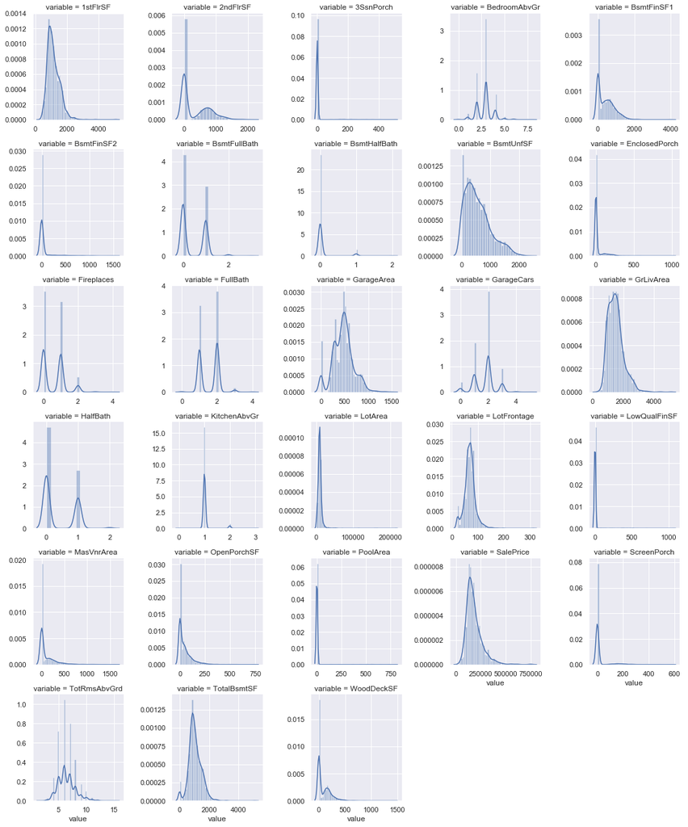

```python
# 观察数值型数据的分布
f = pd.melt(df_all, value_vars = num_col)
g = sns.FacetGrid(f, col = 'variable',  col_wrap = 5, sharex = False, sharey = False)
g = g.map(sns.distplot, 'value')
```

```python
# 'LotFrontage', 'LotArea','BsmtUnfSF', 'TotalBsmtSF', '1stFlrSF', 'GrLivArea'类似于正态分布,对其log处理
log_list = ['LotFrontage', 'LotArea', 'TotalBsmtSF', '1stFlrSF', 'GrLivArea']
for i in log_list:
    df_all[i] = np.log1p(df_all[i])
```

```python
# 针对其余数值型变量，也做标准化处理
num_col2 = num_col.drop(log_list)
num_col2 = num_col.drop('SalePrice')
num_col2_means = df_all.loc[:, num_col2].mean()
num_col2_std = df_all.loc[:, num_col2].std()
df_all.loc[:, num_col2] = (df_all.loc[:, num_col2] - num_col2_means) / num_col2_std
```

```python
# 处理序列型数据
order_col = ['ExterQual', 'ExterCond', 'GarageQual', 'GarageCond','PoolQC','FireplaceQu', 'KitchenQual', 'HeatingQC', 'BsmtQual','BsmtCond']
order_map = {'Ex': 5,'Gd': 4,'TA': 3,'Fa': 2,'Po': 1,'None': 0}

for i in order_col:
    df_all[i] = df_all[i].map(order_map)
```

```python
# 为其他类别属性贴标签
df_all['BsmtExposure'] = df_all['BsmtExposure'].map({'None':0, 'No':1, 'Mn':2, 'Av':3, 'Gd':4})
df_all['BsmtFinType1'] = df_all['BsmtFinType1'].map({'None':0, 'Unf':1, 'LwQ':2,'Rec':3, 'BLQ':4, 'ALQ':5, 'GLQ':6})
df_all['BsmtFinType2'] = df_all['BsmtFinType2'].map({'None':0, 'Unf':1, 'LwQ':2,'Rec':3, 'BLQ':4, 'ALQ':5, 'GLQ':6})
df_all['Functional'] = df_all['Functional'].map({'None':0,'Sal':1, 'Sev':2, 'Maj2':3, 'Maj1':4, 'Mod':5, 'Min2':6, 'Min1':7, 'Typ':8})
df_all['GarageFinish'] = df_all['GarageFinish'].map({'None':0, 'Unf':1, 'RFn':2, 'Fin':3})
df_all['Fence'] = df_all['Fence'].map({'None':0, 'MnWw':1, 'GdWo':2, 'MnPrv':3, 'GdPrv':4})
```

```python
# 为一些类别做1/0处理
df_all['MasVnrType'] = df_all.MasVnrType.replace({'BrkCmn': 1,'BrkFace': 1,'CBlock': 1,'Stone': 1,'None': 0})
df_all['SaleCondition'] = df_all.SaleCondition.replace({'Abnorml': 1,'Alloca': 1,'AdjLand': 1,'Family': 1,'Normal': 0,'Partial': 0})
df_all['CentralAir'] = df_all.CentralAir.replace({'Y': 1,'N': 0})
df_all['PavedDrive'] = df_all.PavedDrive.replace({'Y': 1,'N': 0})
```

```python
# 对售卖月份按照季度做处理
df_all['MoSold'] = df_all['MoSold'].map({'1':1,'2':1,'3':1,'4':2,'5':2,'6':2,'7':3,'8':3,'9':3,'10':4,'11':4,'12':4})
```

```python
num_col, len(num_col)
```

```
(Index(['1stFlrSF', '2ndFlrSF', '3SsnPorch', 'BedroomAbvGr', 'BsmtFinSF1',
        'BsmtFinSF2', 'BsmtFullBath', 'BsmtHalfBath', 'BsmtUnfSF',
        'EnclosedPorch', 'Fireplaces', 'FullBath', 'GarageArea', 'GarageCars',
        'GrLivArea', 'HalfBath', 'KitchenAbvGr', 'LotArea', 'LotFrontage',
        'LowQualFinSF', 'MasVnrArea', 'OpenPorchSF', 'PoolArea', 'SalePrice',
        'ScreenPorch', 'TotRmsAbvGrd', 'TotalBsmtSF', 'WoodDeckSF'],
       dtype='object'), 28)
```

one-hot

```python
df_all_dummy = pd.get_dummies(df_all)
```

```python
df_all_dummy.shape
```

```
(2916, 582)
```

```python
# 将数据集分为训练集和测试集
df_train_dummy = df_all_dummy[df_all_dummy['SalePrice'].notnull()]
df_test_dummy = df_all_dummy[df_all_dummy['SalePrice'].isnull()]
```

```python
df_train_dummy.shape, df_test_dummy.shape
```

```
((1457, 582), (1459, 582))
```

```python
df_train_n = df_train_dummy.drop('SalePrice', axis = 1)
df_test_n = df_test_dummy.drop('SalePrice', axis = 1)
```

### 3. 建模

```python
x_train = df_train_n.values
y_train = np.log1p(df_train_dummy['SalePrice'])
x_test = df_test_n.values
```

```python
# 定义验证函数
def rmse_cv(model):
    rmse= np.sqrt(-cross_val_score(model, x_train, y_train, scoring='neg_mean_squared_error', cv = 10))
    return(rmse)
```

##### Ridge Regression

```python
from sklearn.model_selection import cross_val_score, GridSearchCV, KFold
from sklearn.linear_model import Ridge, RidgeCV
```

```python
clf1 = RidgeCV(np.logspace(-3, 2, 50))
clf1.fit(x_train, y_train)
ridge_pre = np.expm1(clf1.predict(x_test))
score1 = rmse_cv(clf1)
print("\nRidge score: {:.4f} ({:.4f})\n".format(score1.mean(), score1.std()))
```

```
Ridge score: 0.1125 (0.0109)
```

##### Lasso Regression

```python
from sklearn.linear_model import LassoCV, LassoLarsCV
```

```python
clf2 = LassoCV(alphas = [1, 0.1, 0.001, 0.0005,0.0003,0.0002, 5e-4])
clf2.fit(x_train, y_train)
lasso_pre = np.expm1(clf2.predict(x_test))
score2 = rmse_cv(clf2)
print('\nLasso score: {:.4f} ({:.4f})\n'.format(score2.mean(), score2.std()))
```

```
Lasso score: 0.1087 (0.0116)
```

##### ELASTIC NET

```python
from sklearn.linear_model import ElasticNet, ElasticNetCV
```

```python
clf3 = ElasticNetCV(l1_ratio=[.1, .5, .7, .9, .95, .99, 1],alphas=[0.001, 0.05, 0.1, 0.3, 1, 3, 5, 10, 15, 30, 50, 75])
clf3.fit(x_train, y_train)
elastic_pre = np.expm1(clf3.predict(x_test))
score3 = rmse_cv(clf3)
print('\nElastic Net: {:.4f} ({:.4f})\n'.format(score3.mean(), score3.std()))
```

```
Elastic Net: 0.1091 (0.0115)
```

### 5. 输出结果

```python
ridge_pre = np.expm1(clf1.predict(x_test))
lasso_pre = np.expm1(clf2.predict(x_test))
elastic_pre = np.expm1(clf3.predict(x_test))
```

```python
y_final_1 = ridge_pre
y_final_2 = lasso_pre
y_final_3 = elastic_pre
y_final_4 = 0.15 * ridge_pre + 0.6 * lasso_pre + 0.25 * elastic_pre
```

```python
submission_df_1 = pd.DataFrame(data= {'Id': range(1461,2920), 'SalePrice': y_final_1})
submission_df_1.to_csv('predict03-1.csv',index=False)
```

```python
submission_df_2 = pd.DataFrame(data= {'Id': range(1461,2920), 'SalePrice': y_final_2})
submission_df_2.to_csv('predict03-2.csv',index=False)
```

```python
submission_df_3 = pd.DataFrame(data= {'Id': range(1461,2920), 'SalePrice': y_final_3})
submission_df_3.to_csv('predict03-3.csv',index=False)
```

```python
submission_df_4 = pd.DataFrame(data= {'Id': range(1461,2920), 'SalePrice': y_final_4})
submission_df_4.to_csv('predict03-4.csv',index=False)
```